# Redwine quality

1. Title: Wine Quality
2. Sources Created by: Paulo Cortez (Univ. Minho), Antonio Cerdeira, Fernando Almeida, Telmo Matos and Jose Reis (CVRVV) @ 2009
3. Past Usage:

P. Cortez, A. Cerdeira, F. Almeida, T. Matos and J. Reis. Modeling wine preferences by data mining from physicochemical properties. In Decision Support Systems, Elsevier, 47(4):547-553. ISSN: 0167-9236.

In the above reference, two datasets were created, using red and white wine samples. The inputs include objective tests (e.g. PH values) and the output is based on sensory data (median of at least 3 evaluations made by wine experts). Each expert graded the wine quality between 0 (very bad) and 10 (very excellent). Several data mining methods were applied to model these datasets under a regression approach. The support vector machine model achieved the best results. Several metrics were computed: MAD, confusion matrix for a fixed error tolerance (T), etc. Also, we plot the relative importances of the input variables (as measured by a sensitivity analysis procedure).

4. Relevant Information:

The dataset is related to red wine variants of the Portuguese “Vinho Verde” wine. For more details, consult: http://www.vinhoverde.pt/en/ or the reference [Cortez et al., 2009]. Due to privacy and logistic issues, only physicochemical (inputs) and sensory (the output) variables are available (e.g. there is no data about grape types, wine brand, wine selling price, etc.). 5. Number of Instances: red wine - 1599 6. Number of Attributes: 11 + output attribute

# Univariate Plots Section

```
##        X          fixed.acidity   volatile.acidity  citric.acid
##  Min.   :   1.0   Min.   : 4.60   Min.   :0.1200   Min.   :0.000
##  1st Qu.: 400.5   1st Qu.: 7.10   1st Qu.:0.3900   1st Qu.:0.090
##  Median : 800.0   Median : 7.90   Median :0.5200   Median :0.260
##  Mean   : 800.0   Mean   : 8.32   Mean   :0.5278   Mean   :0.271
##  3rd Qu.:1199.5   3rd Qu.: 9.20   3rd Qu.:0.6400   3rd Qu.:0.420
##  Max.   :1599.0   Max.   :15.90   Max.   :1.5800   Max.   :1.000
##  residual.sugar     chlorides       free.sulfur.dioxide
##  Min.   : 0.900   Min.   :0.01200   Min.   : 1.00
##  1st Qu.: 1.900   1st Qu.:0.07000   1st Qu.: 7.00
##  Median : 2.200   Median :0.07900   Median :14.00
##  Mean   : 2.539   Mean   :0.08747   Mean   :15.87
##  3rd Qu.: 2.600   3rd Qu.:0.09000   3rd Qu.:21.00
##  Max.   :15.500   Max.   :0.61100   Max.   :72.00
##  total.sulfur.dioxide    density             pH          sulphates
##  Min.   :  6.00       Min.   :0.9901   Min.   :2.740   Min.   :0.3300
##  1st Qu.: 22.00       1st Qu.:0.9956   1st Qu.:3.210   1st Qu.:0.5500
##  Median : 38.00       Median :0.9968   Median :3.310   Median :0.6200
##  Mean   : 46.47       Mean   :0.9967   Mean   :3.311   Mean   :0.6581
##  3rd Qu.: 62.00       3rd Qu.:0.9978   3rd Qu.:3.400   3rd Qu.:0.7300
##  Max.   :289.00       Max.   :1.0037   Max.   :4.010   Max.   :2.0000
##     alcohol         quality
##  Min.   : 8.40   Min.   :3.000
##  1st Qu.: 9.50   1st Qu.:5.000
##  Median :10.20   Median :6.000
##  Mean   :10.42   Mean   :5.636
##  3rd Qu.:11.10   3rd Qu.:6.000
##  Max.   :14.90   Max.   :8.000
```

Here is the description of various variables in the dataset

```
##   X fixed.acidity volatile.acidity citric.acid residual.sugar chlorides
## 1 1           7.4             0.70        0.00            1.9     0.076
## 2 2           7.8             0.88        0.00            2.6     0.098
## 3 3           7.8             0.76        0.04            2.3     0.092
## 4 4          11.2             0.28        0.56            1.9     0.075
## 5 5           7.4             0.70        0.00            1.9     0.076
## 6 6           7.4             0.66        0.00            1.8     0.075
##   free.sulfur.dioxide total.sulfur.dioxide density   pH sulphates alcohol
## 1                  11                   34  0.9978 3.51      0.56     9.4
## 2                  25                   67  0.9968 3.20      0.68     9.8
## 3                  15                   54  0.9970 3.26      0.65     9.8
## 4                  17                   60  0.9980 3.16      0.58     9.8
## 5                  11                   34  0.9978 3.51      0.56     9.4
## 6                  13                   40  0.9978 3.51      0.56     9.4
##   quality  rating
## 1       5 average
## 2       5 average
## 3       5 average
## 4       6 average
## 5       5 average
## 6       5 average
```

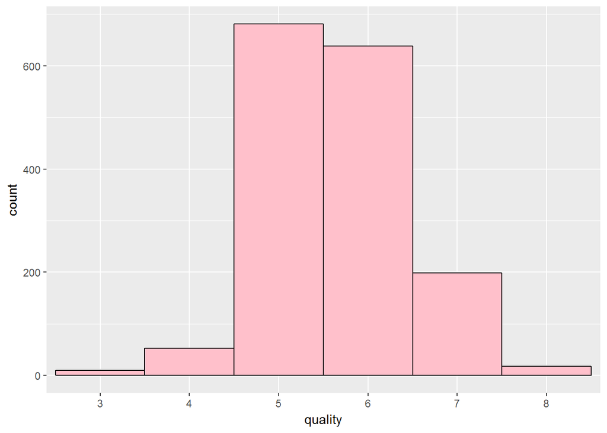

Most of the wines in the dataset are average quality wines

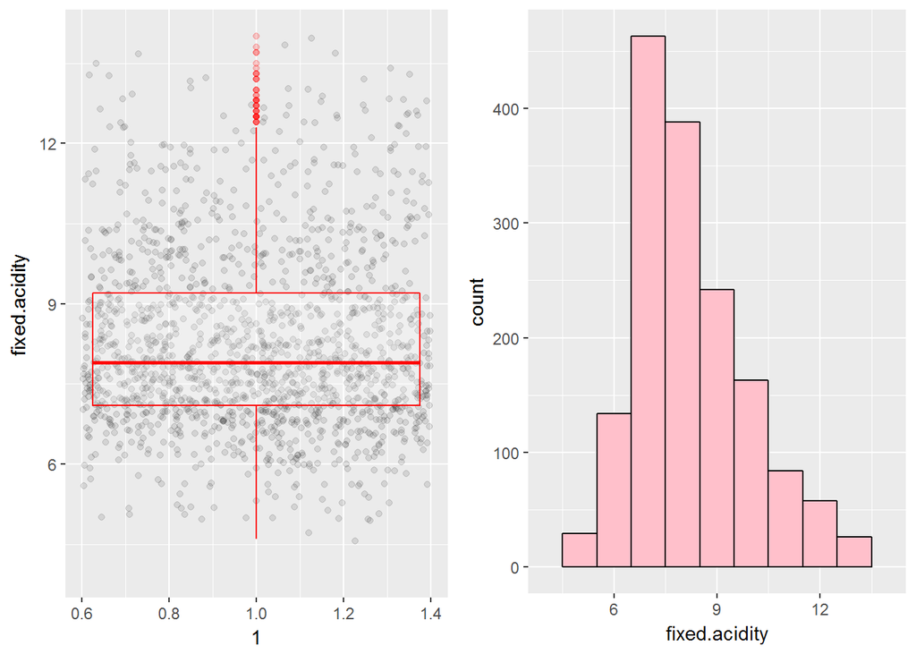

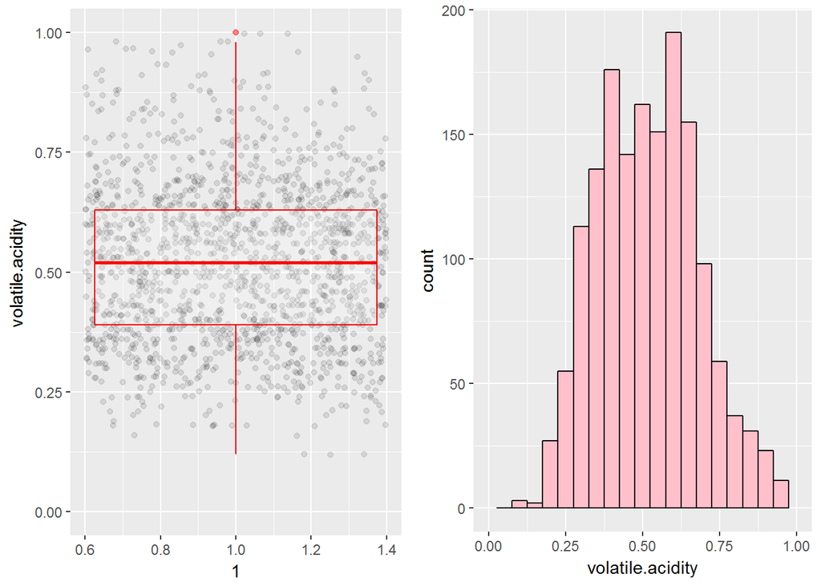

The distribution of Volatile acidity looks is around 0.4 and 0.6.

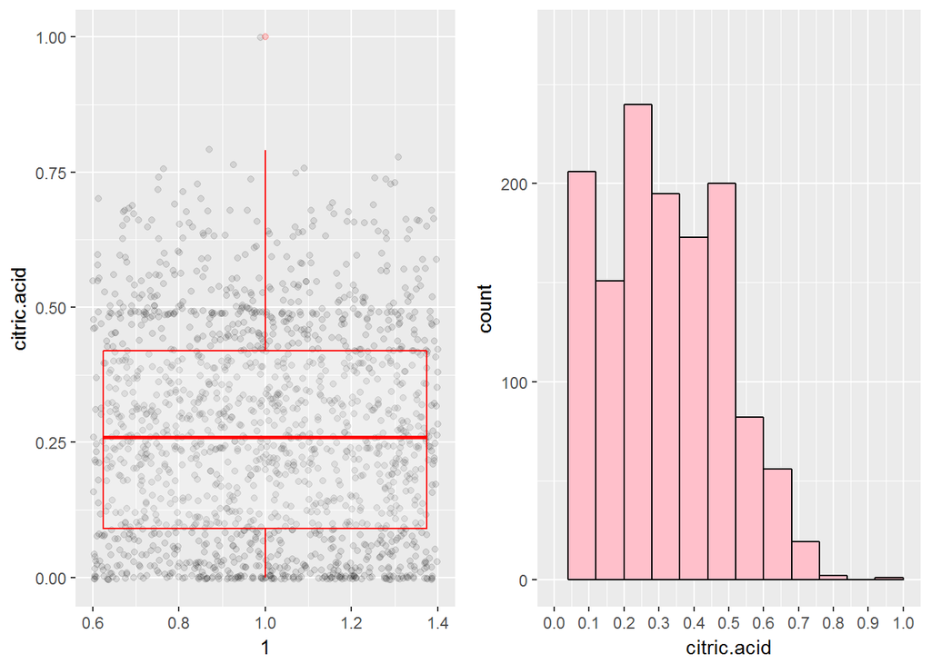

There might be some error in the data.

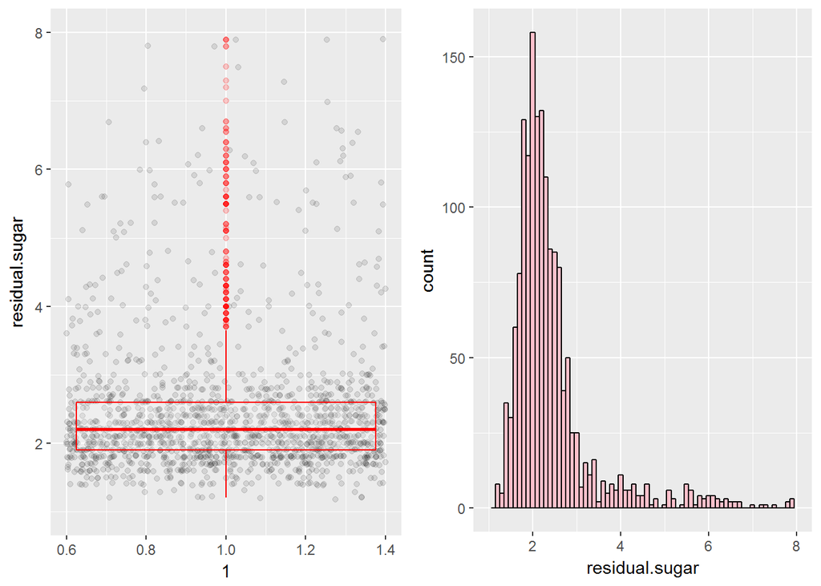

The distribution of residual sugars are around 2.3 with many outliers.

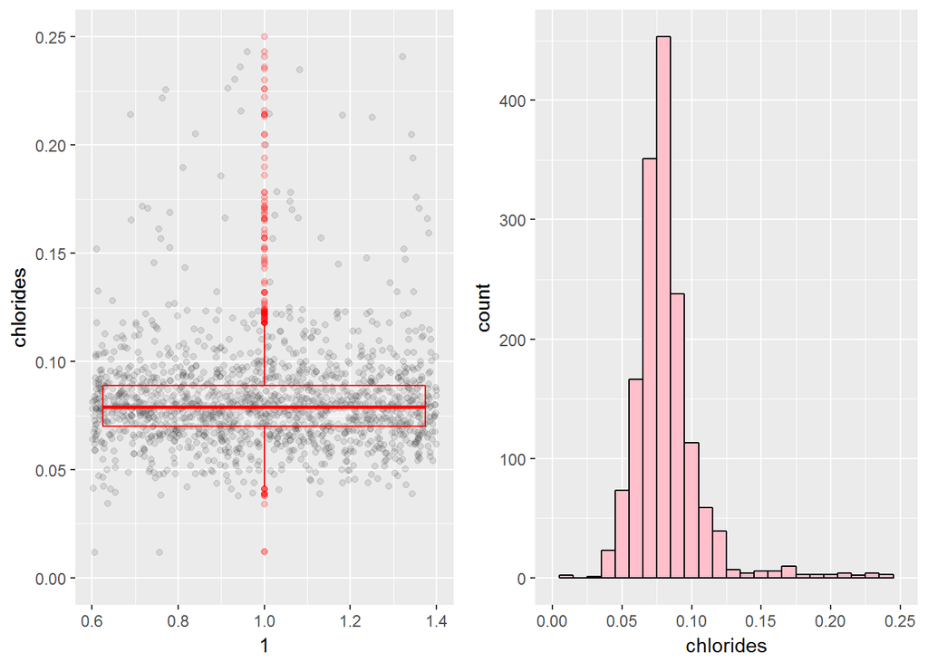

This Histogram For Chlorides also shows that there are outliers and got rid of it.

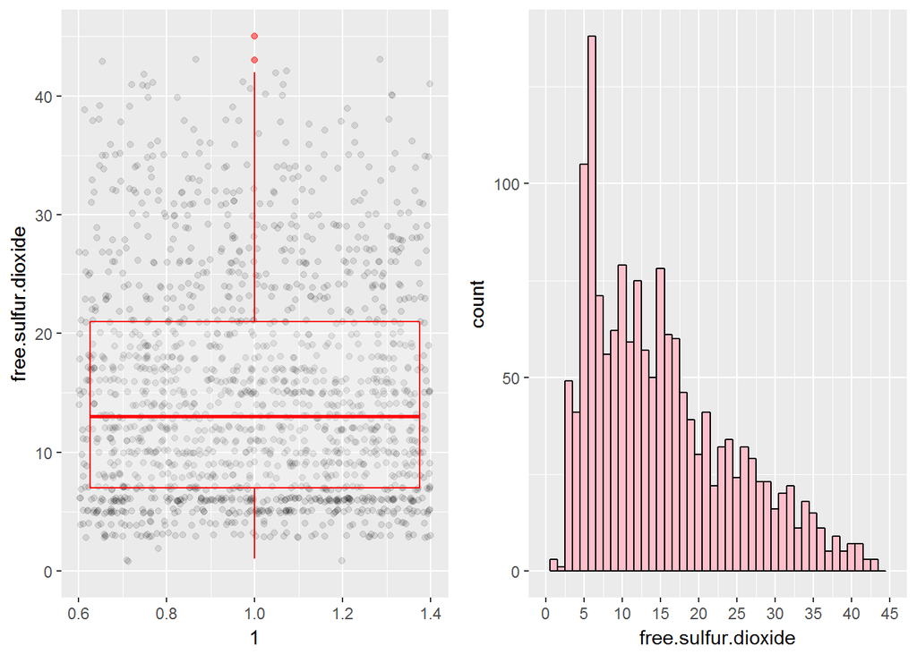

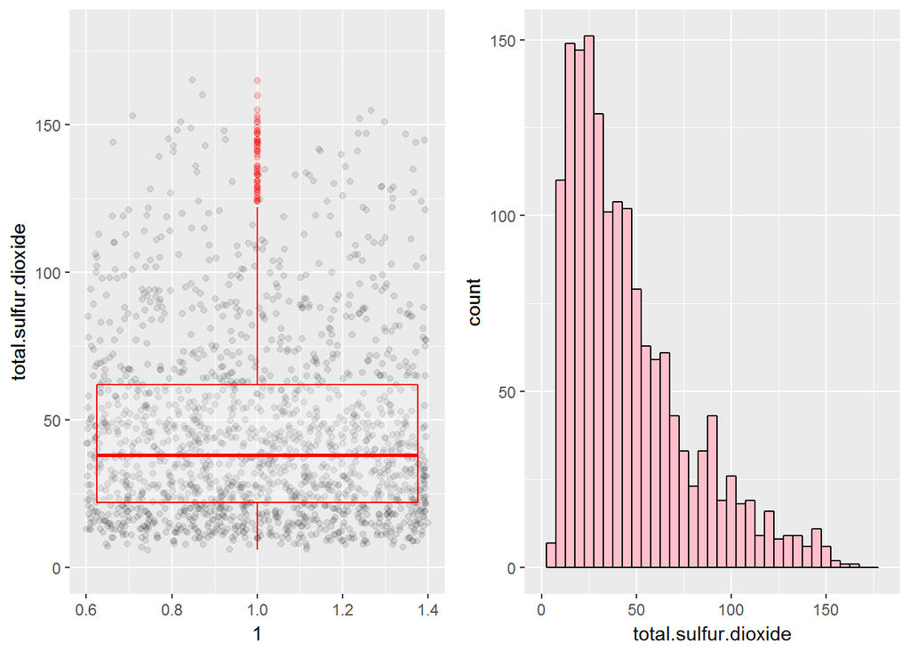

Total Sulphur Dioxide also follows a similar pattern.

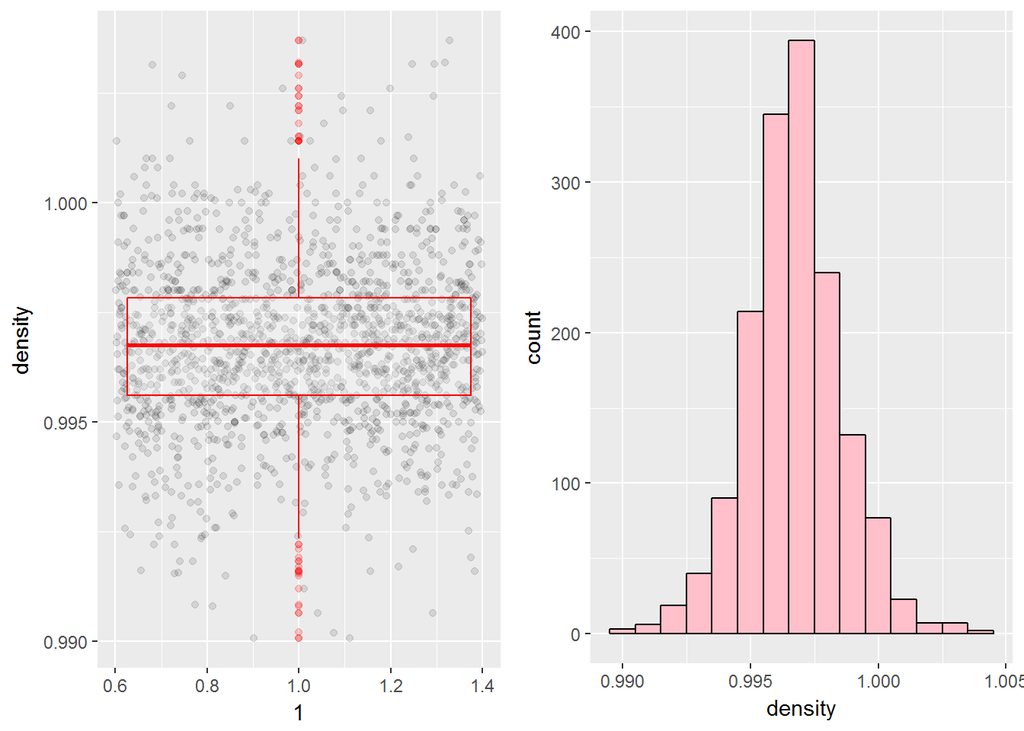

Density has almost a perfect Normal Distribution.

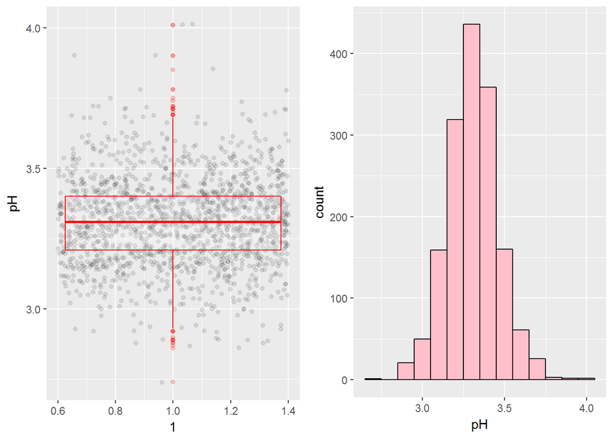

pH has Normal distribution.

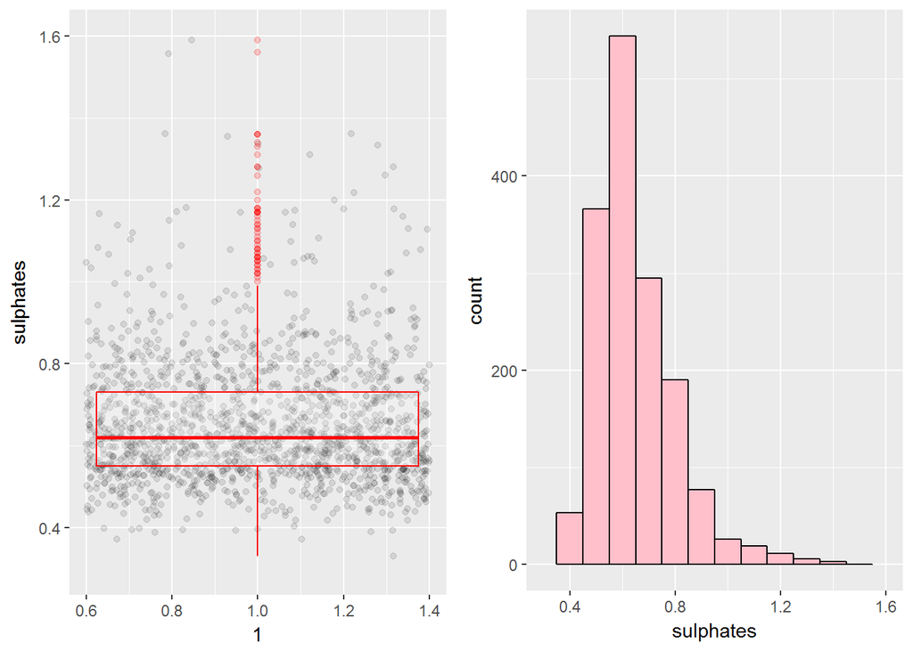

It has relatively less outliers.

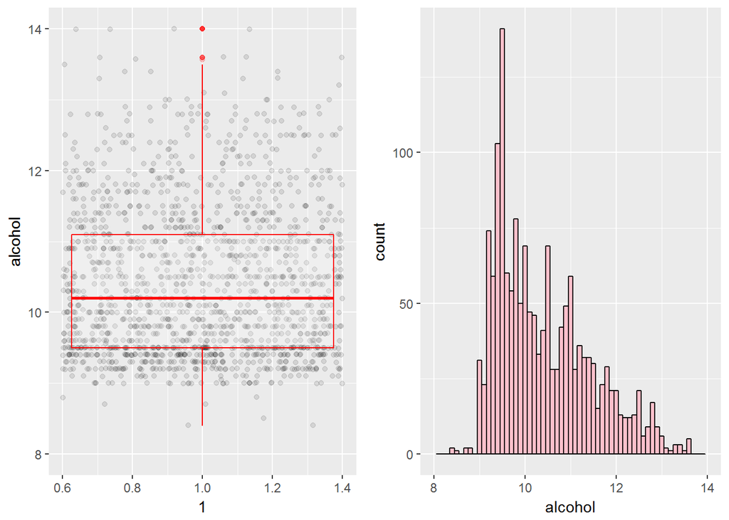

Alcohol has less outliers than that of Chlorides or Residual Sugars.

# UNIVARIATE ANALYSIS

What is the structure of your dataset?

Other observations:

What is/are the main feature(s) of interest in your dataset? The main features in the data set are Quality and alcohol of the wine. I am prety much interseted in finding what other feautures actually decide the quality of the wine.

What other features in the dataset do you think will help support your investigation into your feature(s) of interest?

pH , sulphates,alcohol, and acidity levels would be helpful in finding the best quality wines.

Of the features you investigated, were there any unusual distributions? Did you perform any operations on the data to tidy, adjust, or change the form of the data? If so, why did you do this?

Density and pH seems to have few outliers.Residual sugar and Chloride seems to have extreme outliers. Fixed and volatile acidity, total and free sulfur dioxides, alcohol and sulphates seem to be long-tailed for the outliers present.Citric acid has lmany zeros which might be due to data entry problems.

# Bivariate Plots Section

creation of correlation between the variables.

```
##
## ---------------------------------------------------------------------------
##           &nbsp;            fixed.acidity   volatile.acidity   citric.acid
## -------------------------- --------------- ------------------ -------------
##     **fixed.acidity**             1             -0.2561        **0.6717**
##
##    **volatile.acidity**        -0.2561             1           **-0.5525**
##
##      **citric.acid**         **0.6717**       **-0.5525**           1
##
##     **residual.sugar**         0.1148           0.001918         0.1436
##
##       **chlorides**            0.09371           0.0613          0.2038
##
##  **free.sulfur.dioxide**       -0.1538          -0.0105         -0.06098
##
##  **total.sulfur.dioxide**      -0.1132          0.07647          0.03553
##
##        **density**            **0.668**         0.02203        **0.3649**
##
##           **pH**             **-0.683**          0.2349        **-0.5419**
##
##       **sulphates**             0.183            -0.261        **0.3128**
##
##        **alcohol**            -0.06167          -0.2023          0.1099
##
##        **quality**             0.1241         **-0.3906**        0.2264
## ---------------------------------------------------------------------------
##
## Table: Table continues below
##
##
## ------------------------------------------------------------------------------
##           &nbsp;            residual.sugar   chlorides    free.sulfur.dioxide
## -------------------------- ---------------- ------------ ---------------------
##     **fixed.acidity**           0.1148        0.09371           -0.1538
##
##    **volatile.acidity**        0.001918        0.0613           -0.0105
##
##      **citric.acid**            0.1436         0.2038          -0.06098
```

[output cut: 66 more lines]

```
##
##  **free.sulfur.dioxide**     0.05166      -0.06941      -0.05066
##
##  **total.sulfur.dioxide**    0.04295       -0.2057       -0.1851
##
##        **density**            0.1485     **-0.4962**     -0.1749
##
##           **pH**             -0.1966       0.2056       -0.05773
##
##       **sulphates**             1          0.09359       0.2514
##
##        **alcohol**           0.09359          1        **0.4762**
##
##        **quality**            0.2514     **0.4762**         1
## -------------------------------------------------------------------
```

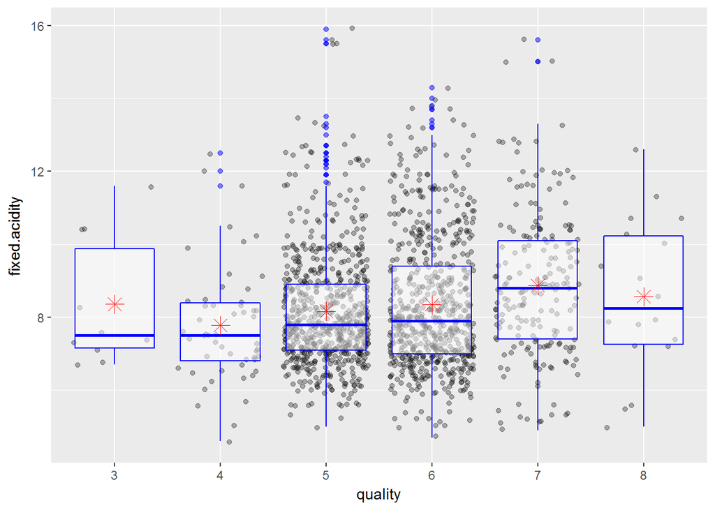

The mean and median values of fixed acidity remains almost unchanged with increase in quality.

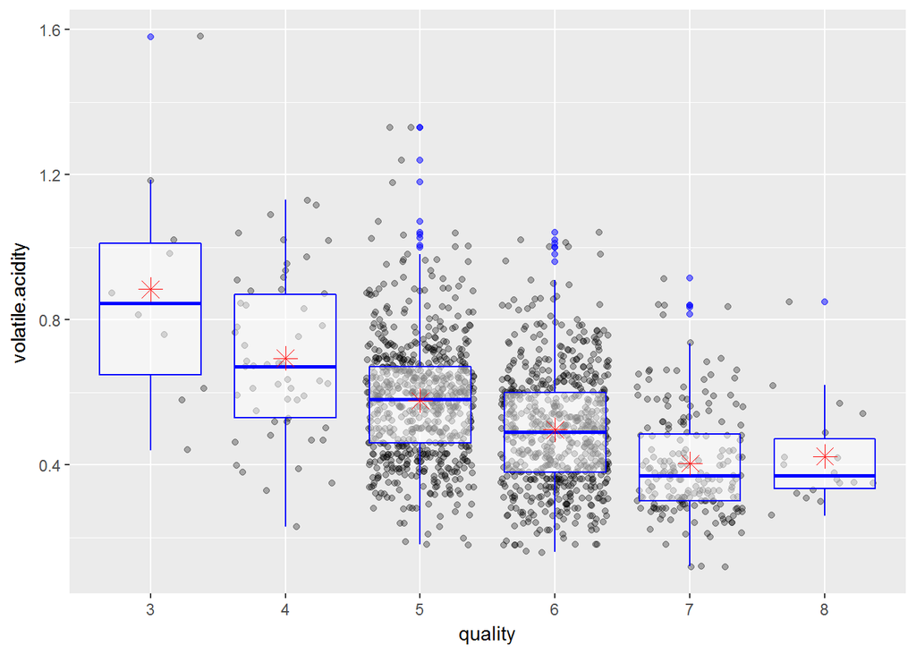

Volatile acid seems to have a negative impact on the quality of the wine.

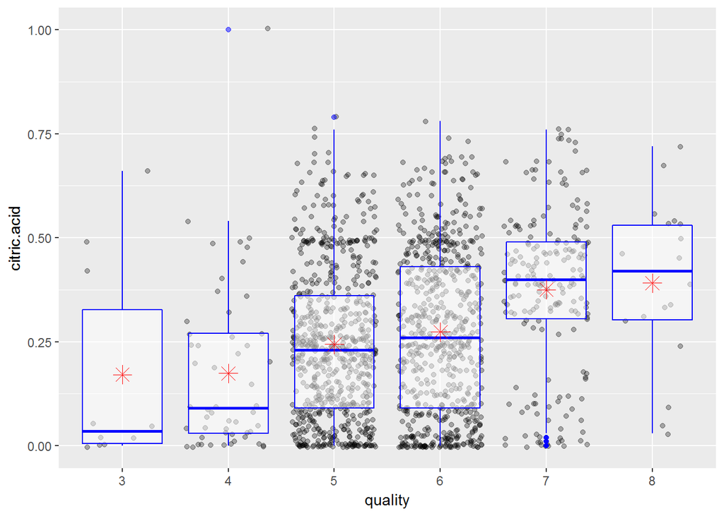

Citric acid seems to have a positive correlation with Wine Quality.

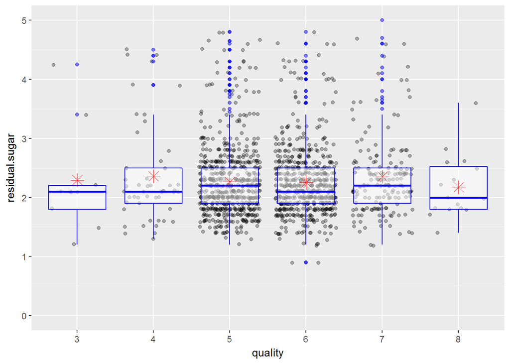

Residual Sugar almost has no effect on the Quality of the Wine

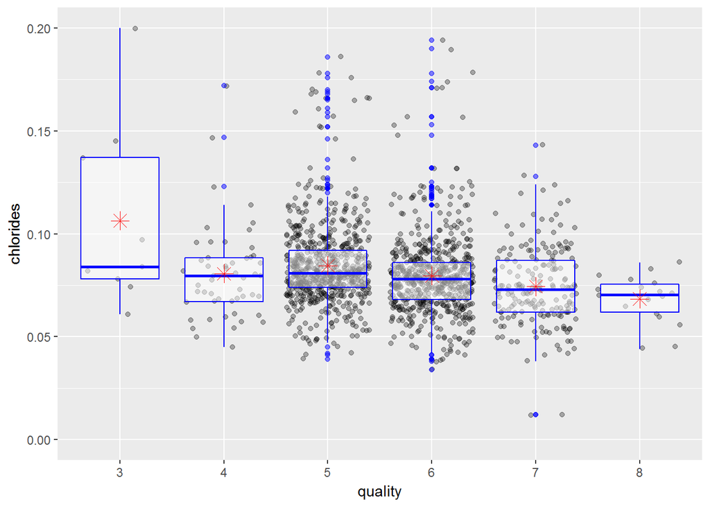

Lower percent of Chloride seems to produce better wines.

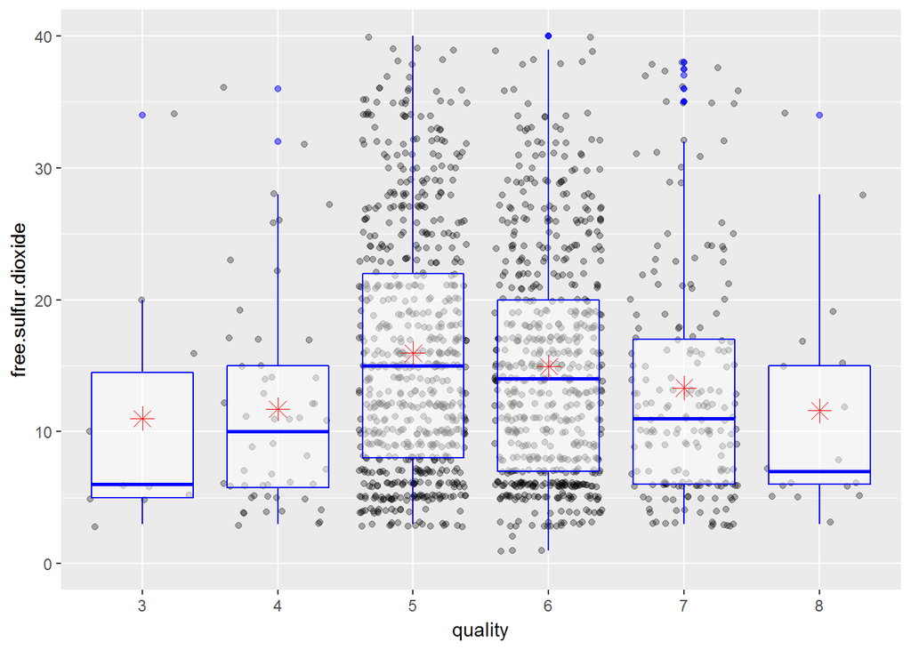

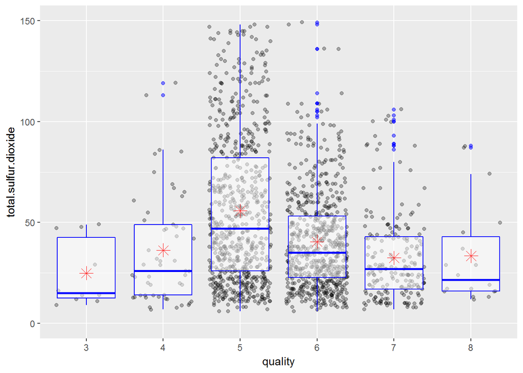

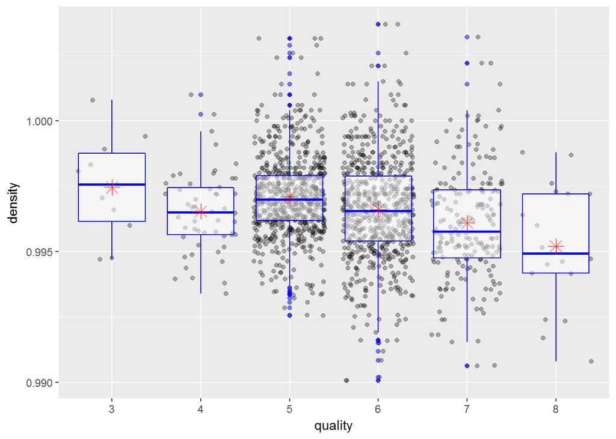

Better wines seems to have lower densities

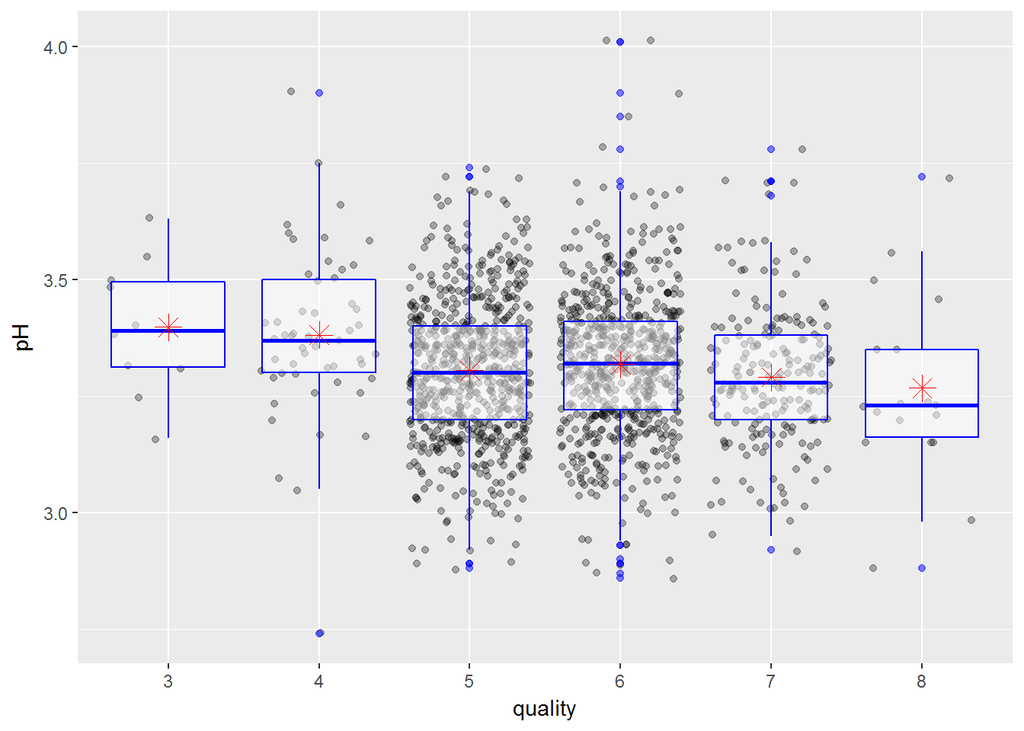

Better wines seems to have less pH,

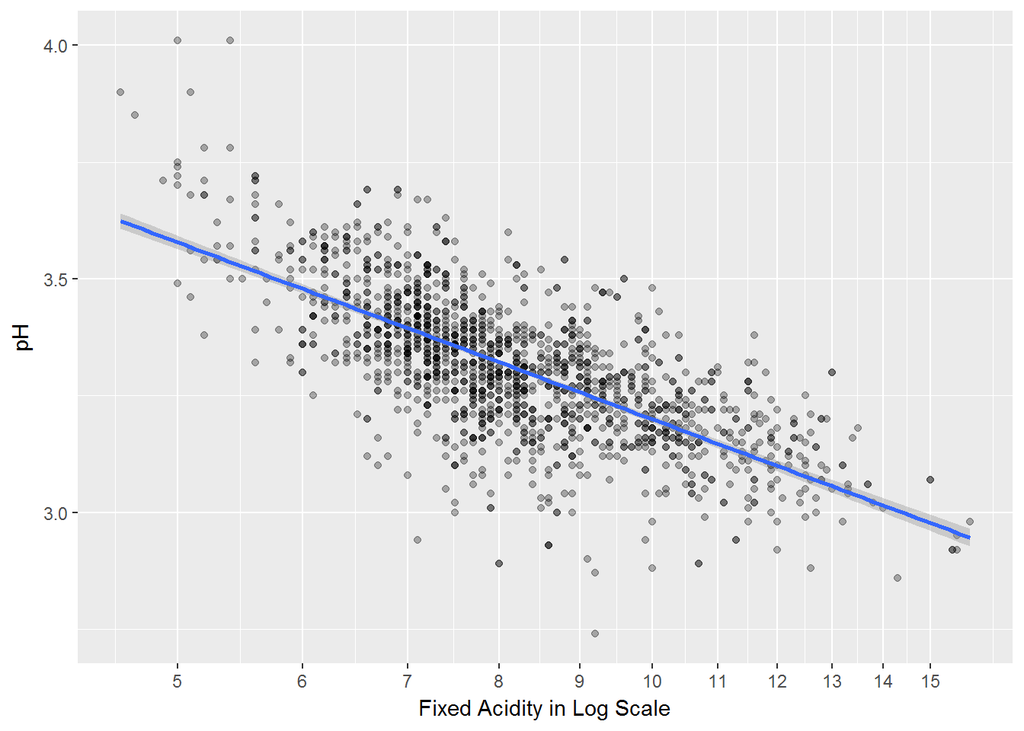

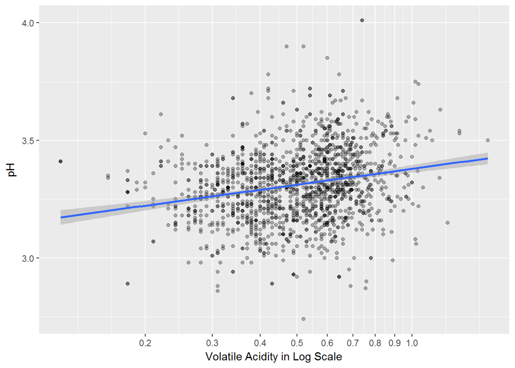

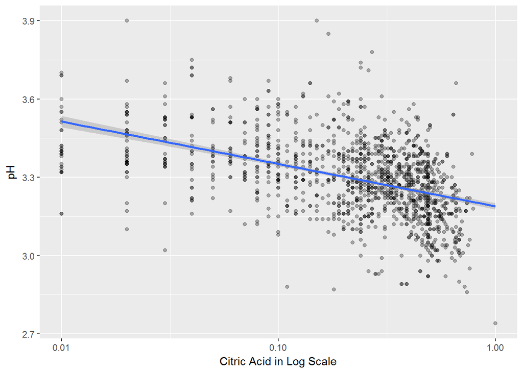

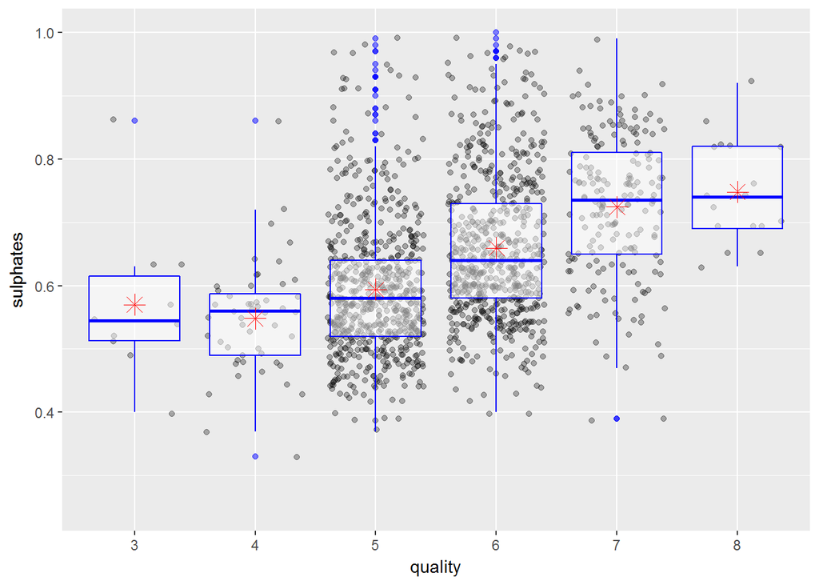

Better wines have a stronger concentration of Sulphates.

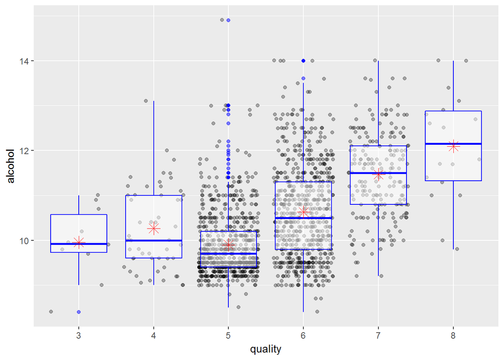

Alcohol alone does not contribute to a wine being a good quality one. Let’s make a simple linear model and understand whats going on.

```
##
## Call:
## lm(formula = as.numeric(quality) ~ alcohol, data = df)
##
## Residuals:
##     Min      1Q  Median      3Q     Max
## -2.8442 -0.4112 -0.1690  0.5166  2.5888
##
## Coefficients:
##             Estimate Std. Error t value Pr(>|t|)
## (Intercept) -0.12503    0.17471  -0.716    0.474
## alcohol      0.36084    0.01668  21.639   <2e-16 ***
## ---
## Signif. codes:  0 '***' 0.001 '**' 0.01 '*' 0.05 '.' 0.1 ' ' 1
##
## Residual standard error: 0.7104 on 1597 degrees of freedom
## Multiple R-squared:  0.2267, Adjusted R-squared:  0.2263
## F-statistic: 468.3 on 1 and 1597 DF,  p-value: < 2.2e-16
```

```
##        fixed.acidity     volatile.acidity          citric.acid
##           0.12405165          -0.39055778           0.22637251
## log10.residual.sugar      log10.chlordies  free.sulfur.dioxide
##           0.02353331          -0.17613996          -0.05065606
## total.sulfur.dioxide              density                   pH
##          -0.18510029          -0.17491923          -0.05773139
##      log10.sulphates              alcohol
##           0.30864193           0.47616632
```

Alcohol,Sulphates(log10),Volatile Acidity,Citric Acid have high concentration of alcohol

# Bivariate Analysis

Talk about some of the relationships you observed in this part of the investigation. How did the feature(s) of interest vary with other features in the dataset?

Fixed Acidity seems to have almost no effect on quality. Volatile Acidity seems to have a negative correlation with the quality. Better wines seem to have higher concentration of Citric Acid. Better wines seem to have higher alcohol percentages. But when I created a linear model around it, I saw from the R squared value that alcohol by itself only contributes like 20% on the variance of the quality. So there may be some other factors at play here. Even though it’s a weak correlation, but lower percent of Chloride seems to produce better quality wines. Better wines seem to have lower densities. But then again, this may be due to the higher alcohol content in them. Better wines seem to be more acidic. Residual sugar almost has no effect on the wine quality. The ideal quality of the wine which is rated as 5 and 6 has chloried conent between 0.5 and 0.6 and alcohol content between 8 and 12 and citric acid does not show much impact on the qualiy of the wine.

Did you observe any interesting relationships between the other features (not the main feature(s) of interest)?

Volatile acidity had a positive correlation with pH.

# Multivariate Plots

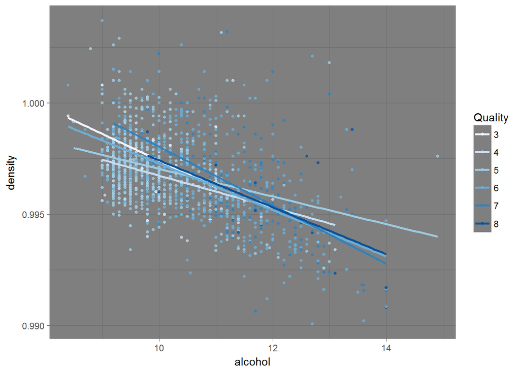

With constant Alcohol, Density does not seem to play a prominet role in changing the quality of the alcohol

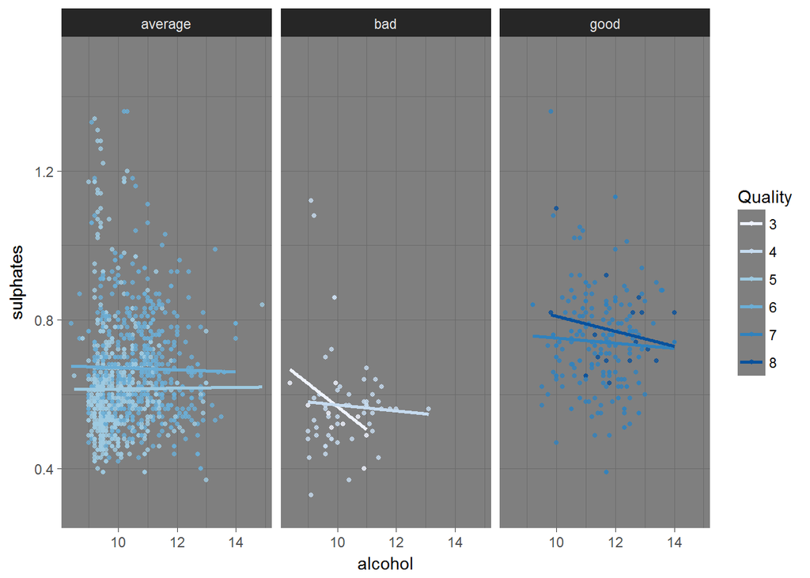

Wines with higher alcohol content produce better wine.

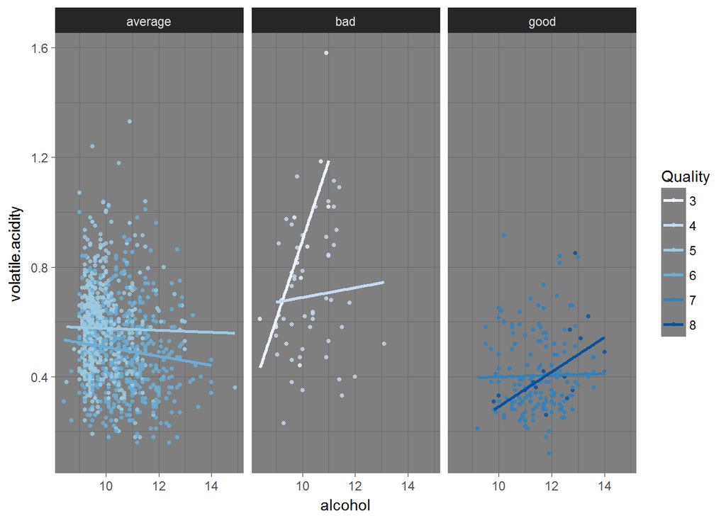

With less concentration of volatile acid and higher concentration of alcohol seems to produce better wines.

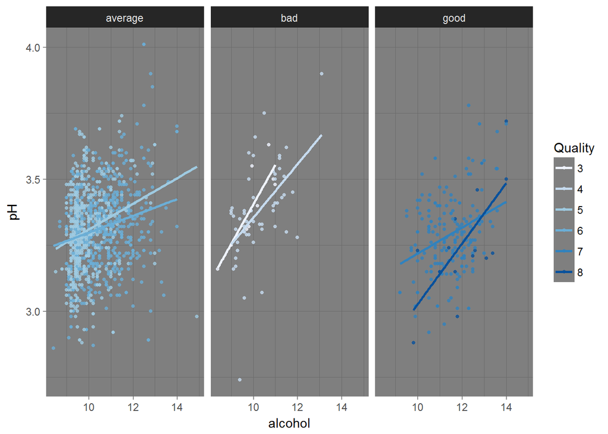

low pH and high Alcohol percentage o produce better wines.

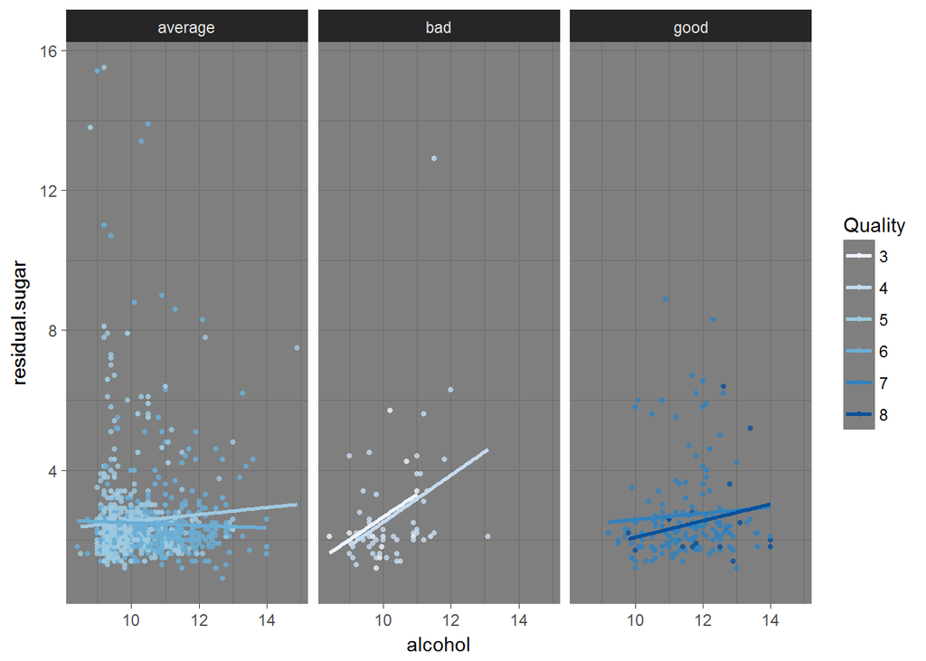

No correlation between residual sugar and quality.

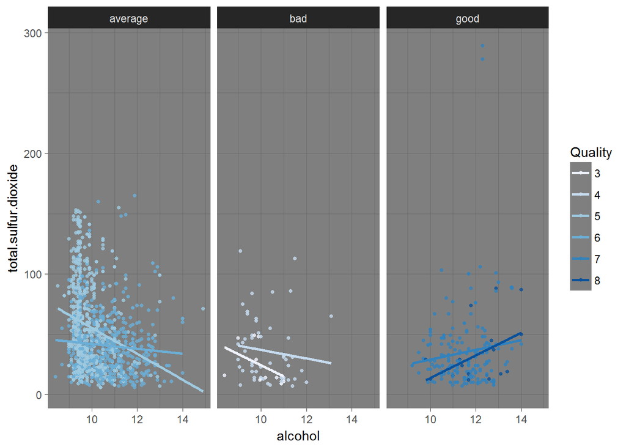

lower Sulphur Dioxide produces better wine even.

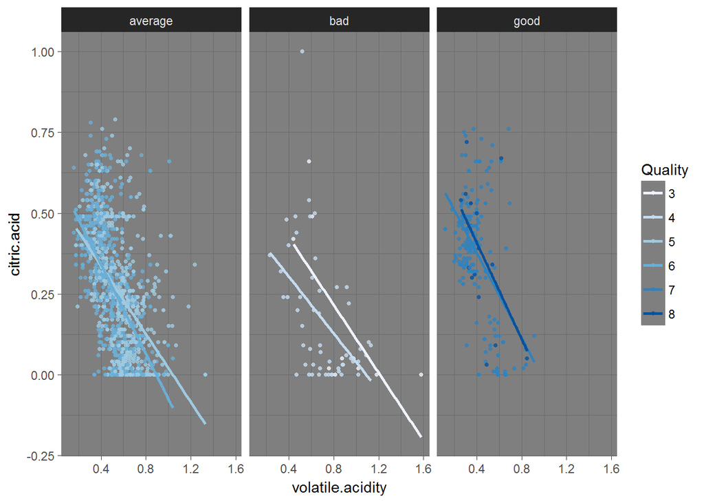

Higher Citric Acid and low Volatile Acid produce better Wines.

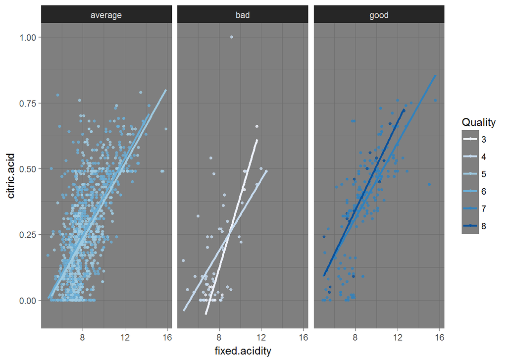

No correlations here.

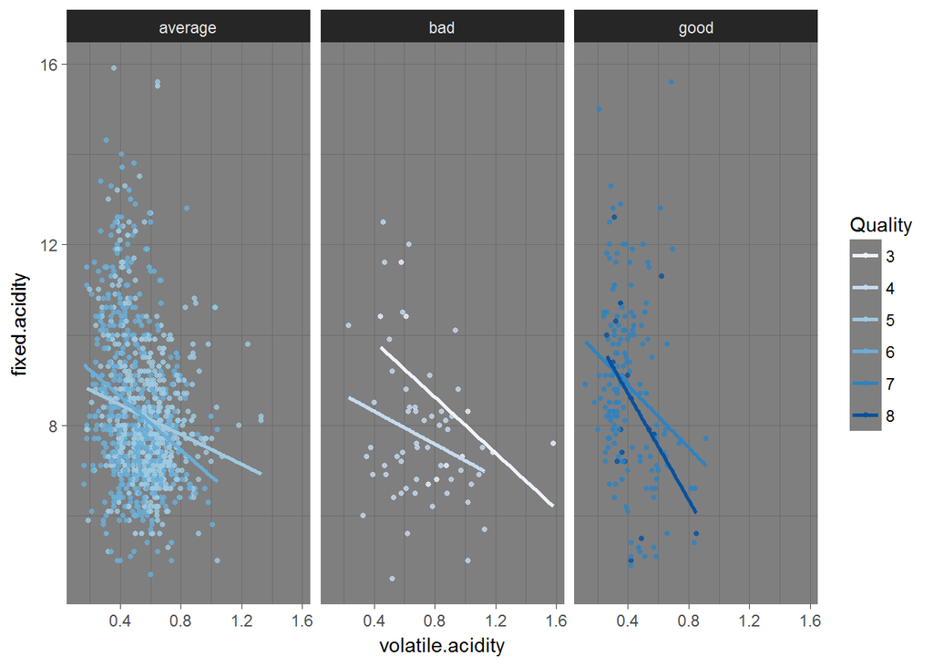

No correlation with the quality.

## Linear Modelling

```
##
## Calls:
## m1: lm(formula = as.numeric(quality) ~ alcohol, data = training_data)
## m2: lm(formula = as.numeric(quality) ~ alcohol + sulphates, data = training_data)
## m3: lm(formula = as.numeric(quality) ~ alcohol + sulphates + volatile.acidity,
##     data = training_data)
## m4: lm(formula = as.numeric(quality) ~ alcohol + sulphates + volatile.acidity +
##     citric.acid, data = training_data)
## m5: lm(formula = as.numeric(quality) ~ alcohol + sulphates + volatile.acidity +
##     citric.acid + fixed.acidity, data = training_data)
## m6: lm(formula = as.numeric(quality) ~ alcohol + sulphates + pH,
##     data = training_data)
##
## ======================================================================================
##                        m1         m2         m3         m4         m5         m6
## --------------------------------------------------------------------------------------
##   (Intercept)       0.155     -0.273      0.866***   0.973***   0.497      1.494**
##                    (0.220)    (0.224)    (0.247)    (0.254)    (0.287)    (0.515)
##   alcohol           0.333***   0.320***   0.286***   0.284***   0.296***   0.339***
##                    (0.021)    (0.021)    (0.020)    (0.020)    (0.020)    (0.021)
##   sulphates                    0.855***   0.599***   0.650***   0.667***   0.733***
##                               (0.126)    (0.124)    (0.127)    (0.126)    (0.129)
##   volatile.acidity                       -1.153***  -1.279***  -1.352***
##                                          (0.124)    (0.143)    (0.144)
##   citric.acid                                       -0.231     -0.629***
##                                                     (0.132)    (0.174)
##   fixed.acidity                                                 0.058***
##                                                                (0.017)
##   pH                                                                      -0.569***
##                                                                           (0.149)
## --------------------------------------------------------------------------------------
##   R-squared             0.2        0.2        0.3        0.3        0.3        0.3
##   adj. R-squared        0.2        0.2        0.3        0.3        0.3        0.3
##   sigma                 0.7        0.7        0.7        0.7        0.7        0.7
##   F                   252.3      155.1      141.8      107.3       89.3      109.7
##   p                     0.0        0.0        0.0        0.0        0.0        0.0
##   Log-likelihood    -1027.5    -1005.0     -963.1     -961.6     -955.6     -997.8
##   Deviance            478.7      456.7      418.5      417.2      411.9      449.8
##   AIC                2061.1     2018.0     1936.3     1935.2     1925.1     2005.6
##   BIC                2075.7     2037.5     1960.6     1964.4     1959.2     2029.9
##   N                   959        959        959        959        959        959
## ======================================================================================
```

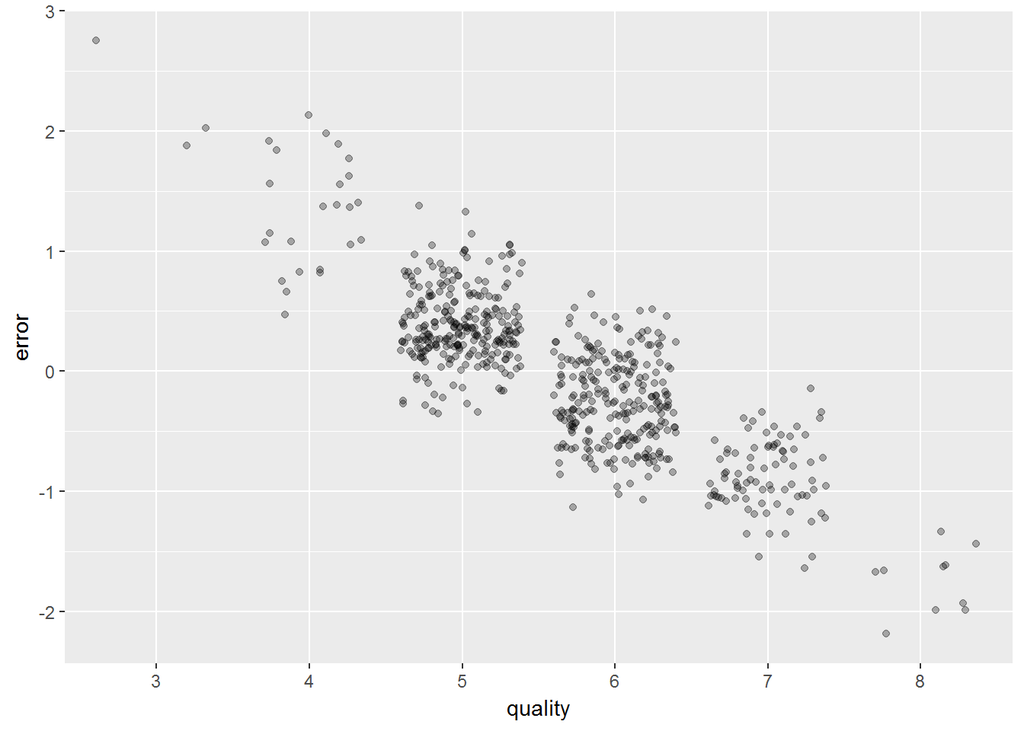

# Plot One

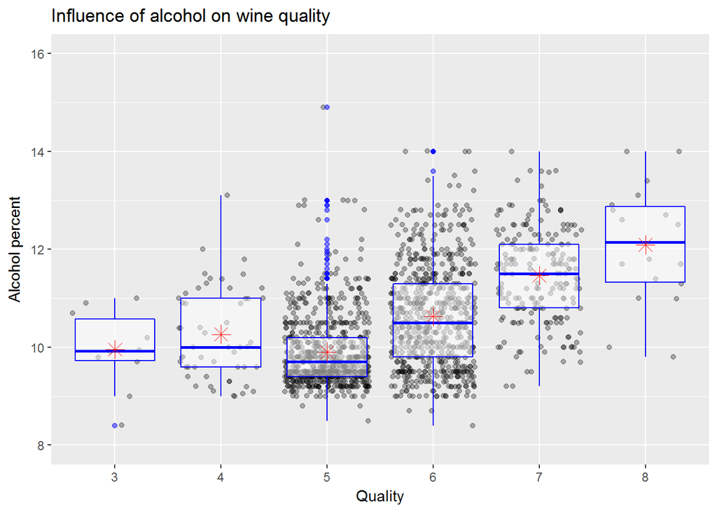

# Description One

Average alcohol percentage in wines is 10% That is most of the wine wine brands usually have 10% of alcohol content.

# Plot Two

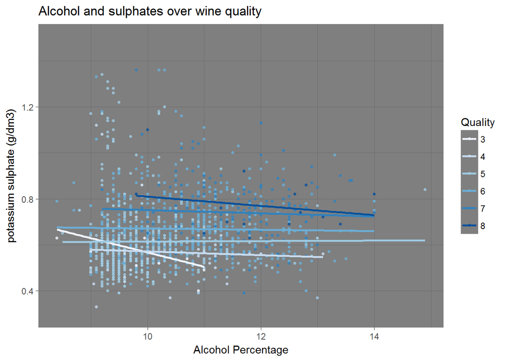

# Description Two

This shows that Alcohol percentage has major impact in finding the quality of Wines. The higher the alcohol percentage, the better the wine quality.

# plot Three

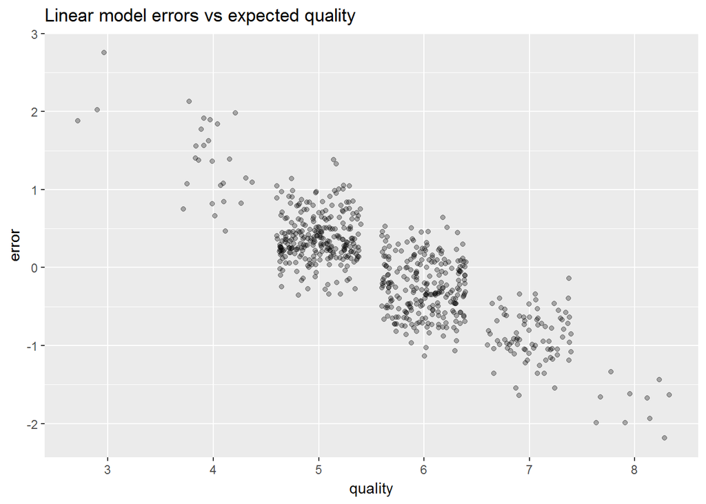

# Description Three

This is evident from the fact that most of our dataset contains ‘Average’ quality wines and there is not too many data in the extreme ranges. The linear model with the R squared value for m5 could only explain around 33% change in quality. Also the earlier models clearly shows that due to the lack of information, it is not the best model to predict both ‘Good’ and ‘Bad’ quality wines.

# Reflection

In this data, my main struggle was to get a higher confidence level when predicting factors that are responsible for the production of different quality of wines especially the ‘Good’ and the ‘Bad’ ones. As the data was very centralized towards the ‘Average’ quality, my training set did not have enough data on the extreme edges to accurately build a model which can predict the quality of a wine given the other variables with lesser margin of error.

I saw that some wines didn’t have citric acid. And the others showed almost a rectangular distribution. citric acid actually is added to some wines to increase the acidity and some wines would not have Citric Acid at all.

The other variables showed either a Positively skewed or a Normal Distribution.

The factors which affected the quality of the wine the most were Alcohol percentage, Sulphate and Acid concentrations.

I tried to figure out the effect of each individual acid on the overall pH of the wine. Here I found out a very peculiar phenomenon where I saw that for volatile acids, the pH was increasing with acidity which was against everything I learned in my Science classes.

During multivariate analysis I found interesting combinations of variables which together affected the overall quality of the wine. That IS Density did not play any part in quality.

For future analysis, if rank and brand details is given for that particular wine, we know when we our opinion changes on so many different factors.